# *Компьютерная работа 2 от группы 12*

## **1. Выделение главных компонент**

#### **1.0. Предварительный анализ**

Загрузим и посмотрим данные:

```r
df <- read.csv('bodyfat.csv')
str(df)
```

```
## 'data.frame':    252 obs. of  15 variables:
##  $ Density: num  1.07 1.09 1.04 1.08 1.03 ...
##  $ BodyFat: num  12.3 6.1 25.3 10.4 28.7 20.9 19.2 12.4 4.1 11.7 ...
##  $ Age    : int  23 22 22 26 24 24 26 25 25 23 ...
##  $ Weight : num  154 173 154 185 184 ...
##  $ Height : num  67.8 72.2 66.2 72.2 71.2 ...
##  $ Neck   : num  36.2 38.5 34 37.4 34.4 39 36.4 37.8 38.1 42.1 ...
##  $ Chest  : num  93.1 93.6 95.8 101.8 97.3 ...
##  $ Abdomen: num  85.2 83 87.9 86.4 100 94.4 90.7 88.5 82.5 88.6 ...
##  $ Hip    : num  94.5 98.7 99.2 101.2 101.9 ...
##  $ Thigh  : num  59 58.7 59.6 60.1 63.2 66 58.4 60 62.9 63.1 ...
##  $ Knee   : num  37.3 37.3 38.9 37.3 42.2 42 38.3 39.4 38.3 41.7 ...
##  $ Ankle  : num  21.9 23.4 24 22.8 24 25.6 22.9 23.2 23.8 25 ...
##  $ Biceps : num  32 30.5 28.8 32.4 32.2 35.7 31.9 30.5 35.9 35.6 ...
##  $ Forearm: num  27.4 28.9 25.2 29.4 27.7 30.6 27.8 29 31.1 30 ...
##  $ Wrist  : num  17.1 18.2 16.6 18.2 17.7 18.8 17.7 18.8 18.2 19.2 ...
```

Удалим признак `Density`, так как зависимая переменная `BodyFat` входит в формулу определения плотности тела и получается, что результаты будут ненадёжными, если не уберём её из исследования.

```r
df <- df[-c(df$Density)]
```

Чтобы приступить к анализу, нам нужно убрать целевую переменную (в нашем случае `BodyFat`) и отнормировать данные:

```r
df_new <- df[-c(1)] #убрали целевую переменную
```

```r
df_scaled <- scale(df_new) #масштабируем данные
df_scaled <- as.data.frame(df_scaled)
```

Давайте, проведём предварительный визуальный анализ распределений отнормированных данных:

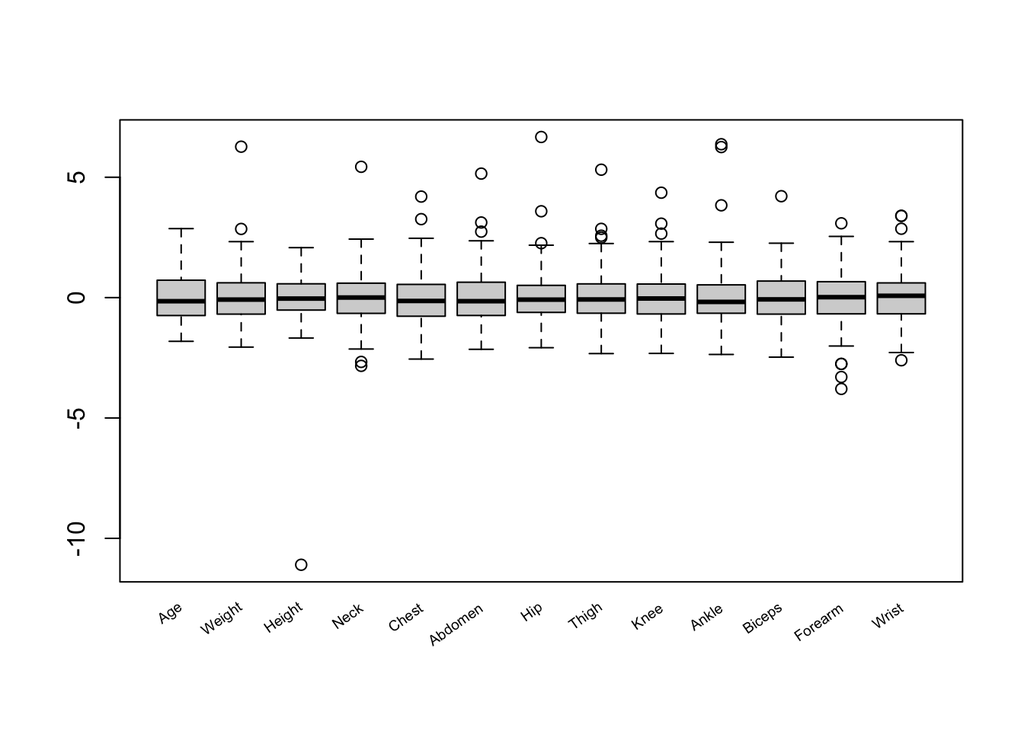

```r
boxplot(df_scaled, xaxt = "n", cex.lab = 0.7)
text(x =  seq_along(names(df_new)), y = par("usr")[3] - 1, srt = 35, adj = 1,
     labels = names(df_new), xpd = TRUE, cex = 0.6)
```

Видим, что среднее значение данных приблизительно равно 0, следовательно, можно предположить, что данные подчиняются нормальному закону распределения.

Одним из самих важных условий построения МГК является мультиколлинеарность, так как размерность можно снизить только в том случае, когда признаки, описывающие совокупность, достаточно коррелированы между собой:

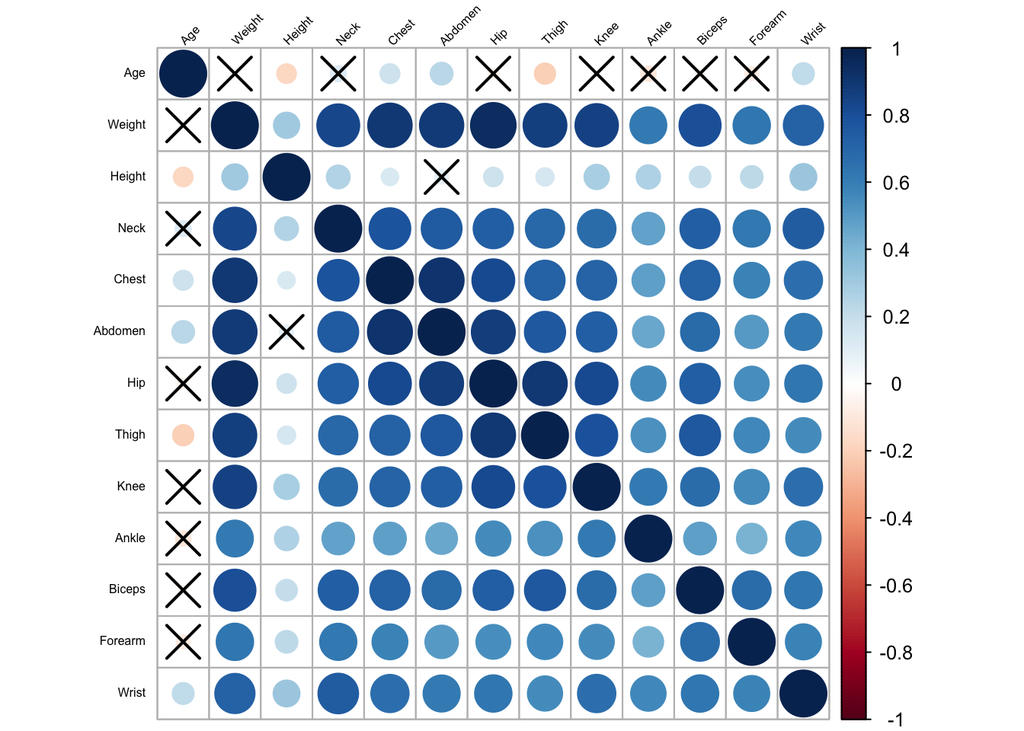

```r
res <- cor.mtest(df_scaled, conf.level = 0.95)
corrplot(cor(df_scaled), p.mat = res$p, type = "full", method = "circle", tl.col = "black", tl.srt = 45, tl.cex = 0.5)
```

Как мы видим, большая часть признаков имеют сильную линейную связь. То есть можно применить МГК. Но чтобы по-настоящему убедиться в этом, нам необходимо провести более обоснованное тестирование - тест сферичности Бартлетта:

```r
bart_spher(df_scaled)
```

```
##  Bartlett's Test of Sphericity
##
## Call: bart_spher(x = df_scaled)
##
##      X2 = 3725.738
##      df = 78
## p-value < 2.22e-16
```

Видим, что p-value значительно меньше 5% уровня значимости, следовательно, нулевая гипотеза об ортогональности переменных отвергается, то есть признаки достаточно коррелированны для того, чтобы применять МГК.

Приступаем к МГК.

#### **1.1. Вывод о числе главных компонент, которые необходимо оставить для дальнейшего анализа с использованием: (a) критерия Кайзера; (b) доли суммарной вариации; (c) критерия каменистой осыпи**

Первым методом будет критерий Кайзера, согласно которому надо выбрать те компоненты, где собственное значение больше 1:

```r
pc <- PCA(df_scaled, graph = FALSE)
pander(pc$eig)
```

|  | eigenvalue | percentage of variance | cumulative percentage of variance |
| --- | --- | --- | --- |
| **comp 1** | 8.04 | 61.85 | 61.85 |
| **comp 2** | 1.355 | 10.42 | 72.27 |
| **comp 3** | 1.002 | 7.71 | 79.98 |
| **comp 4** | 0.6675 | 5.135 | 85.12 |
| **comp 5** | 0.5988 | 4.606 | 89.72 |
| **comp 6** | 0.3138 | 2.413 | 92.14 |
| **comp 7** | 0.2862 | 2.201 | 94.34 |
| **comp 8** | 0.2609 | 2.007 | 96.34 |
| **comp 9** | 0.183 | 1.408 | 97.75 |
| **comp 10** | 0.1342 | 1.032 | 98.78 |
| **comp 11** | 0.07759 | 0.5969 | 99.38 |
| **comp 12** | 0.05696 | 0.4381 | 99.82 |
| **comp 13** | 0.02361 | 0.1816 | 100 |

Визуализируем:

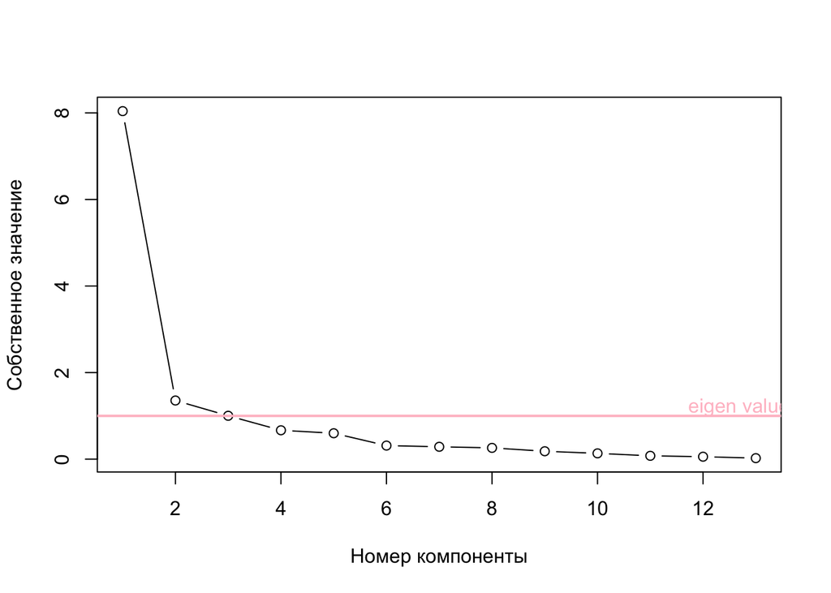

```r
plot(eigen(cor(df_scaled))$values, bstick = TRUE, type = 'b', main = '', xlab = 'Номер компоненты',
     ylab = 'Собственное значение')
abline(h = 1, col = 'pink', lwd = 2)
text(x = 13, y = 1.2, 'eigen value = 1', col = 'pink')
```

Согласно данному методу, оптимальное число компонент - 3.

Второй метод - это определение главных компонентов с помощью доли суммарной вариации, которую нужно сохранить на уровне 70-80%.

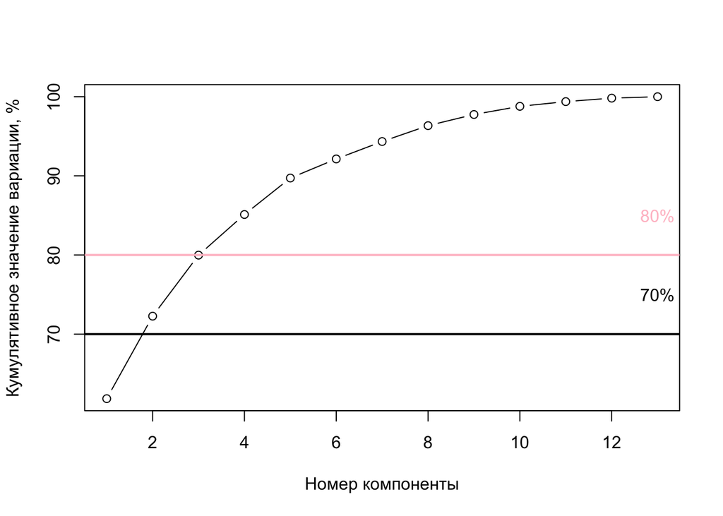

```r
princomp <- princomp(df_scaled, cor = TRUE)
cumvarsum <- cumsum(princomp$sdev^2 / sum(princomp$sdev^2))*100
plot(cumvarsum, bstick = TRUE, type = 'b', main = '', xlab = 'Номер компоненты',
     ylab = 'Кумулятивное значение вариации, %')
abline(h = 70, col = 'black', lwd = 2)
abline(h = 80, col = 'pink', lwd = 2)
text(x = 13, y = 75, '70%', col = 'black')
text(x = 13, y = 85, '80%', col = 'pink')
```

Согласно данному методу оптимальное количество компонент - 2-3.

Последний метод - это “критерий каменистой осыпи”, где нужно выбрать такое число компонент, после которого происходит резкое падение доли сохраненной дисперсии

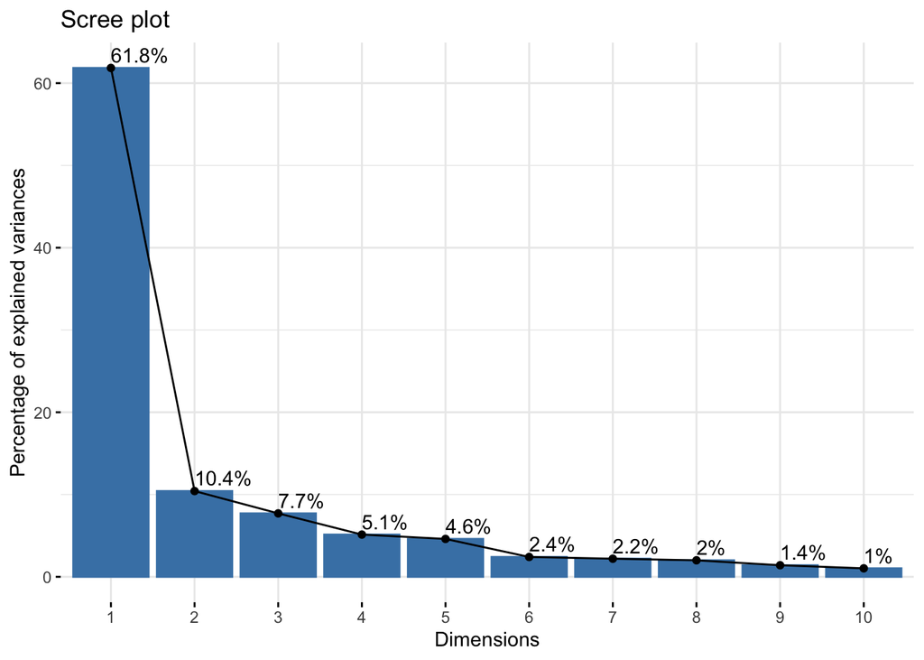

```r
fviz_eig(pc, addlabels = TRUE)
```

Согласно данному методу, оптимальное число компонент - 1.

На основании 3 тестов делаем вывод, что оптимальное число компонент - 3 (2 из 3 методов показали данное значение).

#### **1.2.-1.3. Описание суммарного вклада первых главных компонент. Построение графика накопленного вклада главных компонент в суммарную дисперсию исходного признакового пространства**

Собственные значения и доля суммарной вариации исходного набора признаков, приходящаяся на главные компоненты:

```r
pander(pc$eig)
```

|  | eigenvalue | percentage of variance | cumulative percentage of variance |
| --- | --- | --- | --- |
| **comp 1** | 8.04 | 61.85 | 61.85 |
| **comp 2** | 1.355 | 10.42 | 72.27 |
| **comp 3** | 1.002 | 7.71 | 79.98 |
| **comp 4** | 0.6675 | 5.135 | 85.12 |
| **comp 5** | 0.5988 | 4.606 | 89.72 |
| **comp 6** | 0.3138 | 2.413 | 92.14 |
| **comp 7** | 0.2862 | 2.201 | 94.34 |
| **comp 8** | 0.2609 | 2.007 | 96.34 |
| **comp 9** | 0.183 | 1.408 | 97.75 |
| **comp 10** | 0.1342 | 1.032 | 98.78 |
| **comp 11** | 0.07759 | 0.5969 | 99.38 |
| **comp 12** | 0.05696 | 0.4381 | 99.82 |
| **comp 13** | 0.02361 | 0.1816 | 100 |

Согласно таблице первые 3 компоненты учитывают 79.98% дисперсии. Первая компонента объясняет 61.85% дисперсии, вторая 10.42%, а третья компонента - 7.71%.

Также можно было бы воспользоваться библиотекой `stats`, функцией `princomp` и получили бы те же самые значения:

```r
princomp <- princomp(df_new, cor = TRUE)
summary(princomp)
```

```
## Importance of components:
##                           Comp.1    Comp.2    Comp.3     Comp.4     Comp.5
## Standard deviation     2.8355223 1.1640772 1.0011584 0.81700266 0.77383001
## Proportion of Variance 0.6184759 0.1042366 0.0771014 0.05134564 0.04606253
## Cumulative Proportion  0.6184759 0.7227125 0.7998139 0.85115954 0.89722207
##                            Comp.6     Comp.7     Comp.8     Comp.9    Comp.10
## Standard deviation     0.56013772 0.53494635 0.51078816 0.42776312 0.36626882
## Proportion of Variance 0.02413494 0.02201289 0.02006958 0.01407548 0.01031945
## Cumulative Proportion  0.92135701 0.94336990 0.96343949 0.97751497 0.98783442
##                            Comp.11     Comp.12     Comp.13
## Standard deviation     0.278551451 0.238655835 0.153639313
## Proportion of Variance 0.005968532 0.004381277 0.001815772
## Cumulative Proportion  0.993802950 0.998184228 1.000000000
```

Теперь можем построить график накопленной дисперсии:

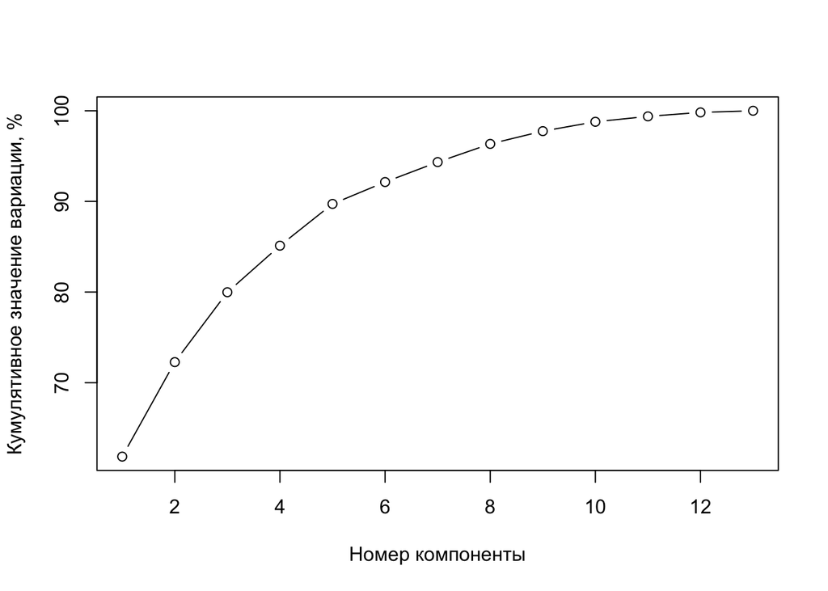

```r
cumvarsum <- cumsum(princomp$sdev^2 / sum(princomp$sdev^2))*100
plot(cumvarsum, bstick = TRUE, type = 'b', main = '', xlab = 'Номер компоненты',
     ylab = 'Кумулятивное значение вариации, %')
```

По графику тоже можно заметить, что после 3 компоненты график становится пологим, что означает, что каждая последующая компонента будет выдавать меньше вклад.

*тут длинный код, который мы решили скрыть, чтобы не захламлять работу*

#### **1.4. Интерпретация главных компонент на основе анализа матрицы факторных нагрузок. Дать названия выделенным главным компонентам**

Как уже ранее говорилось, оптимальное число компонент - 3. Давайте, отобразим матрицу факторных нагрузок:

```r
pca <- principal(cor(df_scaled), nfactors = 3, rotate = "none", covar = FALSE)

pca_loadings <- matrix(as.numeric(pca$loadings), ncol = 3, nrow = ncol(df_scaled))
rownames(pca_loadings) <- colnames(df_scaled)

kbl(round(pca_loadings, 3),
    caption = "Таблица 1. Матрица факторных нагрузок",
    booktabs = T, col.names = c("PC1", "PC2", "PC3")) %>%
    kable_classic(html_font = "Cambria", font_size = 12, full_width = F)
```

Таблица 1. Матрица факторных нагрузок

|  | PC1 | PC2 | PC3 |
| --- | --- | --- | --- |
| Age | 0.028 | 0.874 | 0.420 |
| Weight | 0.977 | -0.021 | -0.039 |
| Height | 0.287 | -0.545 | 0.678 |
| Neck | 0.867 | 0.104 | 0.121 |
| Chest | 0.896 | 0.243 | -0.061 |
| Abdomen | 0.884 | 0.308 | -0.122 |
| Hip | 0.924 | 0.004 | -0.221 |
| Thigh | 0.879 | -0.143 | -0.322 |
| Knee | 0.874 | -0.058 | 0.001 |
| Ankle | 0.654 | -0.261 | 0.128 |
| Biceps | 0.849 | -0.057 | -0.076 |
| Forearm | 0.708 | -0.156 | 0.071 |
| Wrist | 0.791 | 0.094 | 0.388 |

Применим варимакс-вращение и по данной матрице сделаем выводы:

```r
pca <- principal(cor(df_scaled), nfactors = 3, rotate = "varimax", covar = FALSE)

pca_loadings <- matrix(as.numeric(pca$loadings), ncol = 3, nrow = ncol(df_scaled))
rownames(pca_loadings) <- colnames(df_scaled)

kbl(round(pca_loadings, 3),
    caption = "Таблица 2. Матрица факторных нагрузок с варимакс-вращением",
    booktabs = T, col.names = c("PC1", "PC2", "PC3")) %>%
    kable_classic(html_font = "Cambria", font_size = 12, full_width = F)
```

Таблица 2. Матрица факторных нагрузок с варимакс-вращением

|  | PC1 | PC2 | PC3 |
| --- | --- | --- | --- |
| Age | 0.003 | -0.100 | 0.965 |
| Weight | 0.951 | 0.227 | 0.012 |
| Height | 0.063 | 0.909 | -0.096 |
| Neck | 0.817 | 0.265 | 0.197 |
| Chest | 0.903 | 0.052 | 0.222 |
| Abdomen | 0.911 | -0.035 | 0.245 |
| Hip | 0.946 | 0.052 | -0.064 |
| Thigh | 0.915 | 0.034 | -0.244 |
| Knee | 0.839 | 0.252 | -0.003 |
| Ankle | 0.577 | 0.405 | -0.122 |
| Biceps | 0.833 | 0.183 | -0.044 |
| Forearm | 0.653 | 0.318 | -0.059 |
| Wrist | 0.679 | 0.470 | 0.324 |

Факторные нагрузки показывают корреляцию между переменными и компонентой. Чем больше связь между переменной и компонентой, к той компоненте и относится переменная.

Первая компонента - Weight, Neck, Chest, Abdomen, Hip, Thigh, Knee, Biceps, Wrist, Ankle, Forearm, Wrist.

Вторая - Height.

Третья - Age.

Первая компонента представляет собой совокупность антропометрических характеристик для оценки пропорций тела человека. Вторая и третья компоненты состоят из одной характеристики: рост и возраст соответственно.

Дадим названия нашим компонентам:

1. Измерения тела (Weight, Neck, Chest, Abdomen, Hip, Thigh, Knee, Biceps, Wrist, Ankle, Forearm, Wrist).

2. Рост (Height).

3. Возраст (Age).

## **2. Построение уравнения регрессии с использованием выделенных ГК**

#### **2.1. Построение линейного уравнения регрессии на ГК**

```r
Q1 <- quantile(df$BodyFat, .25)
IQR <- IQR(df$BodyFat)
df1 <- subset(df, df$BodyFat > (Q1 - 1.5*IQR)) #убираем выбросы
pc <- as.data.frame(pc$ind$coord[, 1:3])
pc1 <- pc$Dim.1 #выделяем 1-ую компоненту
pc2 <- pc$Dim.2 #выделяем 2-ую компоненту
pc3 <- pc$Dim.3 #выделяем 3-ю компоненту
lm_GK <- lm(df1$BodyFat ~ pc1 + pc2 + pc3) #построение регрессионной модели
pander(summary(lm_GK))
```

|  | Estimate | Std. Error | t value | Pr(>\|t\|) |
| --- | --- | --- | --- | --- |
| **(Intercept)** | 19.15 | 0.3422 | 55.96 | 1.145e-142 |
| **pc1** | 1.829 | 0.1207 | 15.15 | 3.717e-37 |
| **pc2** | 2.831 | 0.294 | 9.629 | 7.544e-19 |
| **pc3** | -1.718 | 0.3418 | -5.027 | 9.556e-07 |

Fitting linear model: df1$BodyFat ~ pc1 + pc2 + pc3

| Observations | Residual Std. Error | $R^2$ | Adjusted $R^2$ |
| --- | --- | --- | --- |
| 252 | 5.433 | 0.5836 | 0.5786 |

Данной моделью объясняется приблизительно 58% вариации зависимой переменной исходя из значения Adjusted $R^2$. Также подмечаем, что `p-value` всех компонент меньше 5% уровня значимости, что ещё раз подтверждает, что они являются значимыми для модели.

#### **2.2. Сопоставление свойств ранее полученных уравнений регрессии (линейное и нелинейное уравнения регрессии) с уравнением регрессии на ГК**

Мы получаем 3 уравнения регрессии:

1. Линейная регрессия (`lm1`):

$$y_{BodyFat} = -21.54 + 0.07198 \cdot
x_{Age} - 0.08279 \cdot x_{Weight} - 0.489 \cdot x_{Neck} + 0.9204 \cdot
x_{Abdomen} - 0.2162 \cdot x_{Hip} + 0.3359 \cdot x_{Thigh} + 0.5175
\cdot x_{Forearm} - 1.511 \cdot x_{Wrist} +ε_i$$

Характеристика линейной регрессии:

|  | Estimate | Std. Error | t value | Pr(>\|t\|) |
| --- | --- | --- | --- | --- |
| **(Intercept)** | -21.54 | 11.69 | -1.843 | 0.06657 |
| **Age** | 0.07198 | 0.03089 | 2.33 | 0.02063 |
| **Weight** | -0.08279 | 0.03999 | -2.07 | 0.03948 |
| **Neck** | -0.489 | 0.2242 | -2.181 | 0.03015 |
| **Abdomen** | 0.9204 | 0.07318 | 12.58 | 2.983e-28 |
| **Hip** | -0.2162 | 0.1385 | -1.56 | 0.12 |
| **Thigh** | 0.3359 | 0.1302 | 2.581 | 0.01045 |
| **Forearm** | 0.5175 | 0.1856 | 2.787 | 0.005736 |
| **Wrist** | -1.511 | 0.5078 | -2.976 | 0.003217 |

Fitting linear model: BodyFat ~ Age + Weight + Neck + Abdomen + Hip + Thigh + Forearm + Wrist

| Observations | Residual Std. Error | $R^2$ | Adjusted $R^2$ |
| --- | --- | --- | --- |
| 251 | 4.267 | 0.7373 | 0.7287 |

2. Нелинейная регрессия (`lm1_1`):

|  | Estimate | Std. Error | t value | Pr(>\|t\|) |
| --- | --- | --- | --- | --- |
| **(Intercept)** | -6.068 | 2.501 | -2.426 | 0.01601 |
| **Age** | 0.137 | 0.08274 | 1.656 | 0.09914 |
| **Weight** | -0.4779 | 0.4667 | -1.024 | 0.3069 |
| **Neck** | -1.206 | 0.5279 | -2.284 | 0.02326 |
| **Abdomen** | 4.787 | 0.4313 | 11.1 | 2.722e-23 |
| **Hip** | -2.116 | 0.8689 | -2.435 | 0.01563 |
| **Thigh** | 1.307 | 0.4979 | 2.624 | 0.009251 |
| **Forearm** | 0.696 | 0.3358 | 2.073 | 0.0393 |
| **Wrist** | -1.482 | 0.5859 | -2.529 | 0.0121 |

Fitting linear model: BodyFat ~ Age + Weight + Neck + Abdomen + Hip + Thigh + Forearm + Wrist

| Observations | Residual Std. Error | $R^2$ | Adjusted $R^2$ |
| --- | --- | --- | --- |
| 244 | 0.2693 | 0.6663 | 0.655 |

3. Уравнение регрессии на ГК (`lm_GK`):

$$y_{BodyFat} = 19.15 + 1.829 \cdot
Component_{1} + 2.831 \cdot Component_{2} - 1.718 \cdot
Component_{3} +ε_i$$

1. Проверим подчиняются ли остатки моделей нормальному распределению c помощью теста Харке-Бера:

**`lm1`:**

Jarque Bera Test: `lm1$residuals`

| Test statistic | df | P value |
| --- | --- | --- |
| 2.291 | 2 | 0.318 |

**`lm1_1`:**

Jarque Bera Test: `lm1_1$residuals`

| Test statistic | df | P value |
| --- | --- | --- |
| 14.3 | 2 | 0.0007864 * * * |

**`lm_GK`:**

Jarque Bera Test: `lm_GK$residuals`

| Test statistic | df | P value |
| --- | --- | --- |
| 1.186 | 2 | 0.5527 |

2. Проверка остатков на независимость с помощью теста Дарбина-Ватсона:

**`lm1`:**

```r
durbinWatsonTest(lm1)
```

```
##  lag Autocorrelation D-W Statistic p-value
##    1      0.09771022      1.796854    0.08
##  Alternative hypothesis: rho != 0
```

**`lm1_1`:**

```r
durbinWatsonTest(lm1_1)
```

```
##  lag Autocorrelation D-W Statistic p-value
##    1       0.1110061      1.772938   0.064
##  Alternative hypothesis: rho != 0
```

**`lm_GK`:**

```r
durbinWatsonTest(lm_GK)
```

```
##  lag Autocorrelation D-W Statistic p-value
##    1       0.1126364        1.7735   0.066
##  Alternative hypothesis: rho != 0
```

Во всех моделях выполнена гипотеза о некоррелируемости остатков, так как `p-value` больше 5%-го уровня значимости.

3. Проверка на гомоскедастичность с помощью графиков:

**`lm1`:**

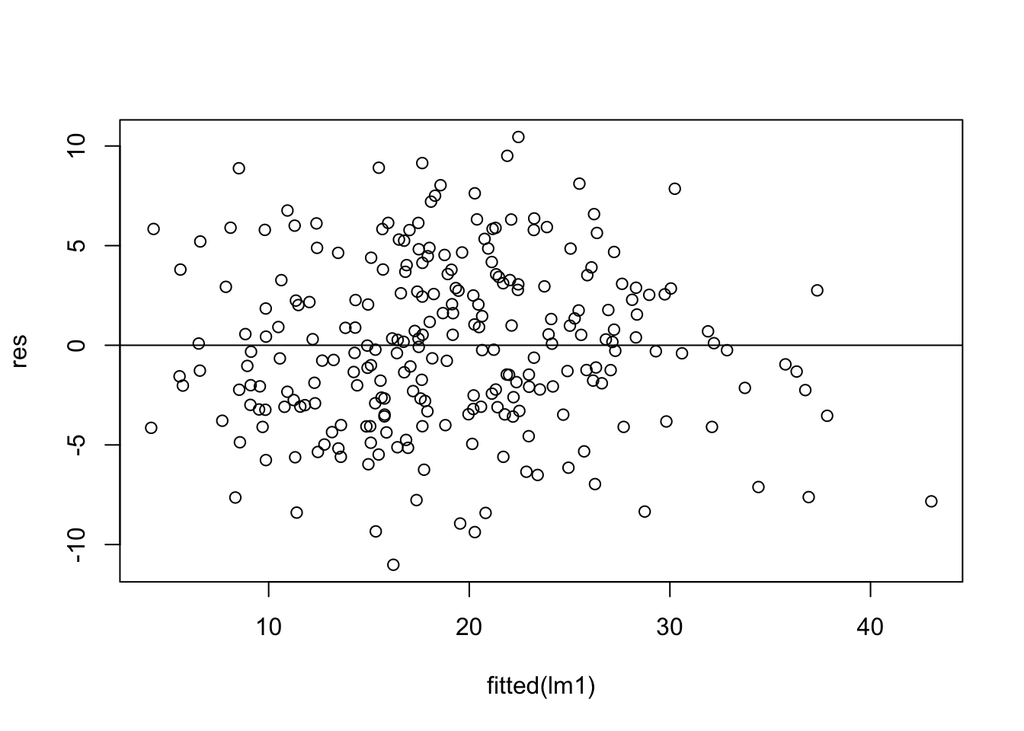

```r
res <- resid(lm1)
plot(fitted(lm1),res)
abline(0,0)
```

**`lm1_1`:**

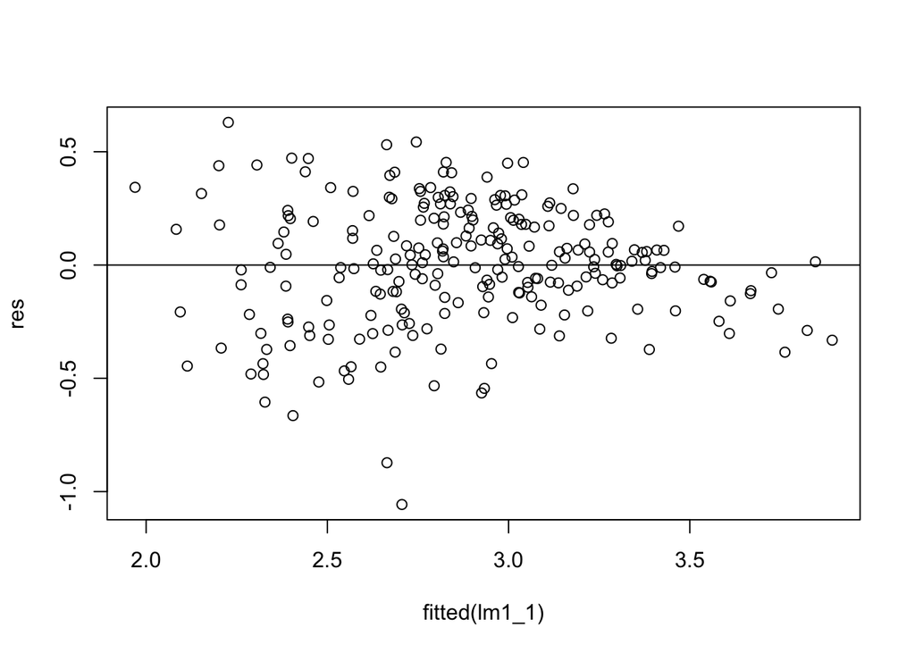

```r
res <- resid(lm1_1)
plot(fitted(lm1_1),res)
abline(0,0)
```

**`lm_GK`:**

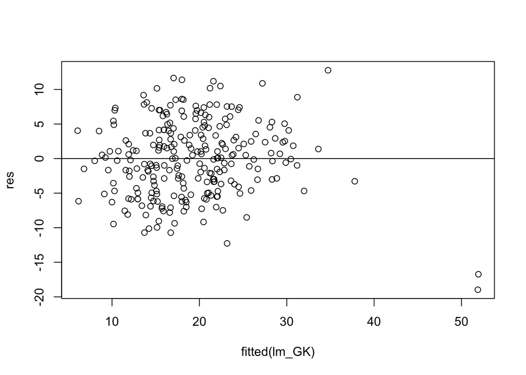

[output not shown]

```r
res <- resid(lm_GK)
plot(fitted(lm_GK),res)
abline(0,0)
```

Гетероскедастичность определяет равномерно ли разбросаны остатки. Из-за присутствия гетероскедастичности данных результатам регрессионного анализа трудно доверять. На графике для степенной модели мы видим закономерность - остатки становятся менее разбросанными с ростом поборанного значения, такая форма разброса - признак гетероскедастичсноти, поэтому лучше не использовать степенную модель.

Если сравнивать модели `lm1` и `lm_GK`, можно сделать предварительный вывод, что первая модель лучше, так как ее скорректированный коэффициент детерминации значительно выше.

Теперь перейдём к сравнению линейной регрессионной модели и регрессионной модели на главных компонентам с помощью информационного критерия.

#### **2.3. Выбор и обоснование лучшего уравнения**

Таблица 3. Информационные критерии Акаике и Шварца (Баесовский инф. критерий)

| Модель | Значение AIC | Значение BIC |
| --- | --- | --- |
| lm1 | 1451.448 | 1486.703 |
| lm_GK | 1574.114 | 1591.761 |

## **3. Кластерный анализ**

Перед проведением кластеризации выделим 4 наблюдения из датасета, чтобы потом использовать их в дискриминантном анализе:

```r
set.seed(1)
rand_df <- df[sample(nrow(df), size = 4), ]
rand_df
```

```
##     BodyFat Age Weight Height Neck Chest Abdomen   Hip Thigh Knee Ankle Biceps
## 249    33.6  72 201.00  69.75 40.9 108.5   105.0 104.5  59.6 40.8  23.2   35.2
## 68     13.8  55 154.75  71.50 36.9  95.4    86.6  91.8  54.3 35.4  21.5   32.8
## 167    21.8  35 166.25  68.00 38.5  99.1    90.4  95.6  55.5 34.2  21.9   30.2
## 129    20.8  40 192.25  73.25 39.8 103.9    93.5  99.5  61.7 39.0  21.8   33.3
##     Forearm Wrist
## 249    28.6  20.1
## 68     27.4  18.7
## 167    28.7  17.7
## 129    29.6  18.1
```

Удалим эти наблюдения из основного датафрейма и масштабируем их:

```r
df_del <- df[-c(249, 68, 167, 129),]
df_del_scaled <- as.data.frame(scale(df_del[-c(1)]))
```

#### **3.1. Построение и анализ дендрограмм**

Отбор классифицирующих признаков:

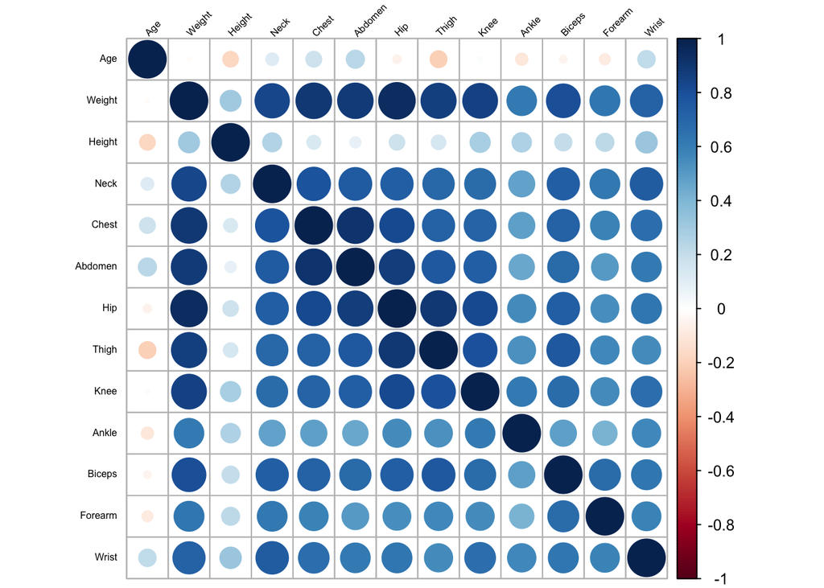

```r
corrplot(cor(scale(df_new)), type = "full", method = "circle", tl.col = "black", tl.srt = 45, tl.cex = 0.5)
```

Для опредления оптимального числа кластеров воспользуемся разными способами.

1. Метод локтя (elbow method):

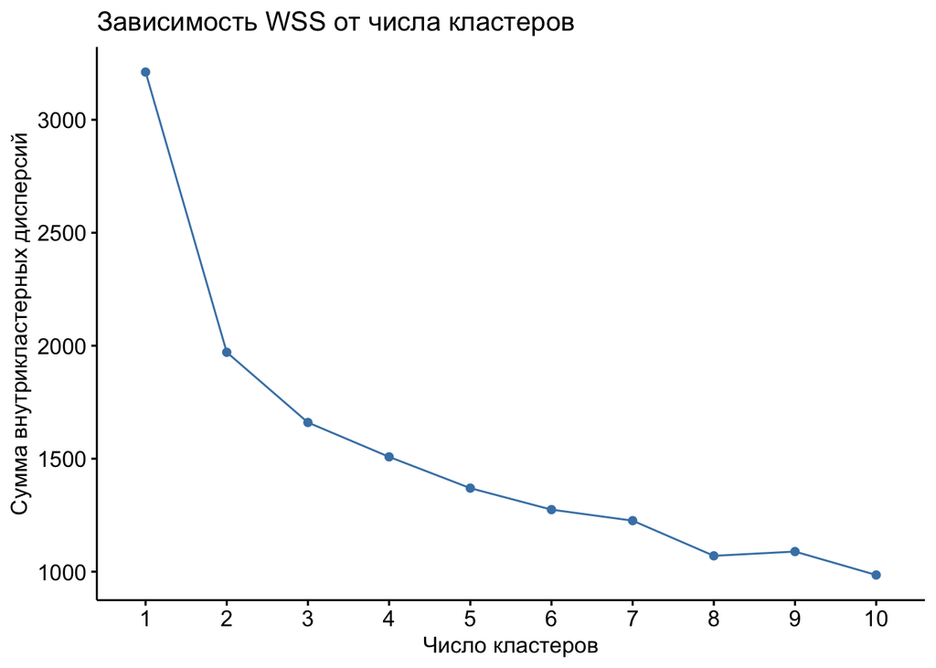

```r
fviz_nbclust(df_del_scaled , kmeans, method = 'wss') +
  labs(x = 'Число кластеров', y = 'Сумма внутрикластерных дисперсий',
       title = 'Зависимость WSS от числа кластеров')
```

В данном случае выбираем 2 кластера, так как у второго кластера прирост суммы внутрикластерной дисперсии резко сокращается.

2. Метод силуэтов (silhouettes):

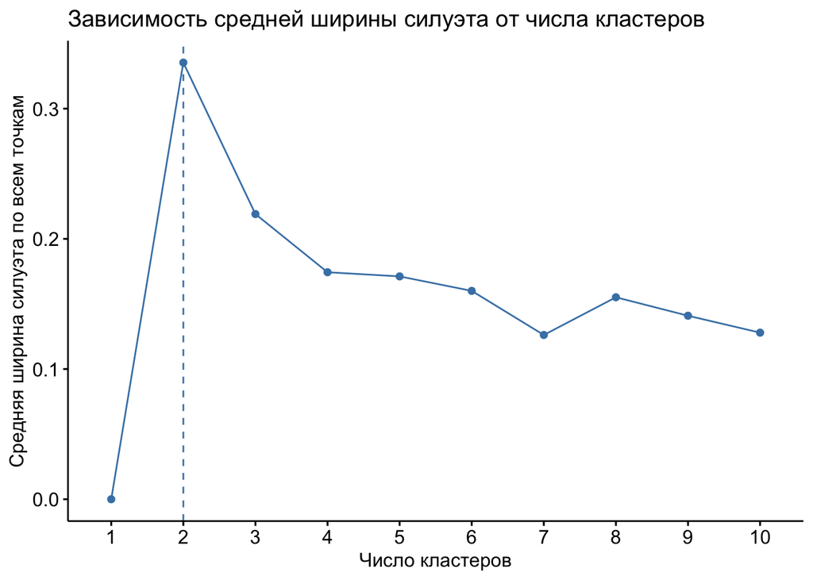

```r
fviz_nbclust(df_del_scaled, kmeans, method = 'silhouette') +
  labs(x = 'Число кластеров', y = 'Средняя ширина силуэта по всем точкам',
       title = 'Зависимость средней ширины силуэта от числа кластеров')
```

Чем ближе средняя ширина силуэта по всем точкам к 1, тем лучше. В данном случае наибольшее значение будет достагиться в точке с двумя (2) кластерами.

3. Статистикой разрыва (Gap-статистика):

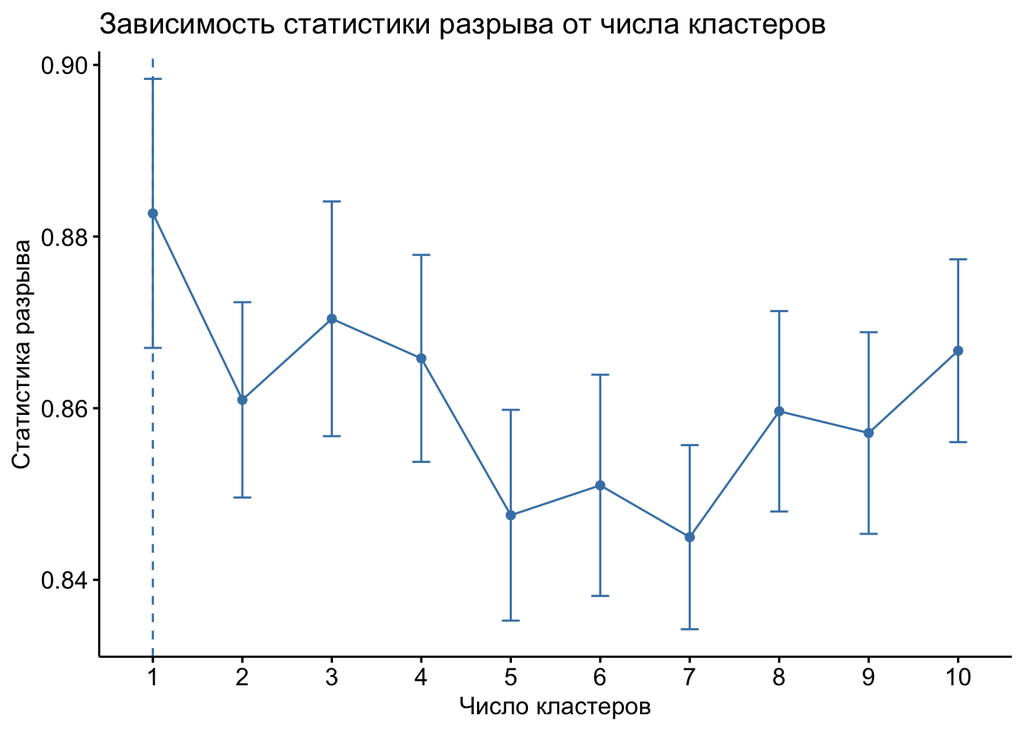

```r
fviz_nbclust(df_del_scaled, kmeans, method = 'gap_stat') +
  labs(x = 'Число кластеров', y = 'Статистика разрыва',
       title = 'Зависимость статистики разрыва от числа кластеров')
```

При двух кластерах статистика разрыва меньше, чем в случае с одним кластером, поэтому согласно этому методу лучше отказаться от деления данных на кластеры.

Получаем, что два теста указывают на разбиение на два кластера, а по итогам последнего от деления на кластеры лучше отказаться.

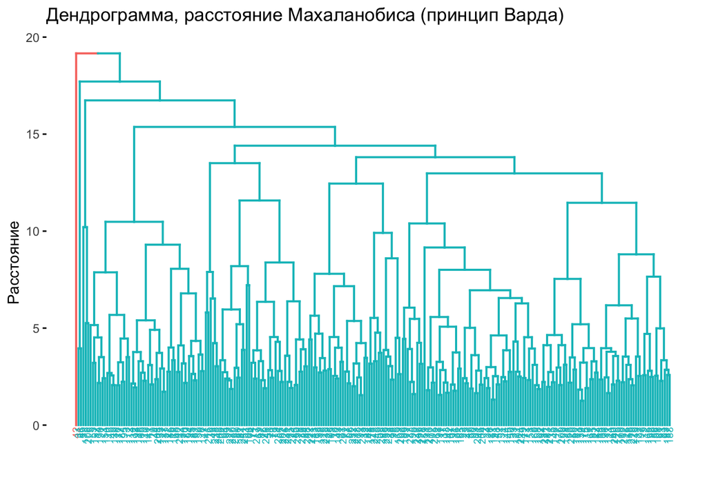

```r
mahalnobis <- sqrt(D2.dist(df_del_scaled, cov(df_del_scaled)))

hclust <- hclust(mahalnobis, method = 'ward.D2')
hclust$cluster <- cutree(hclust, k = 2)

fviz_dend(hclust, cex = 0.5,  k = 2, color_labels_by_k = TRUE,
          main = 'Дендрограмма, расстояние Махаланобиса (принцип Варда)', ylab = 'Расстояние')
```

Разделение на кластеры по полученному графику некорректно, так как в результате мы получаем два кластера, один из которых включает в себя только одно значения, в то время как остальные данные находятся во втором кластере. Причиной такого разделения может оказаться однородность данных и некорректность проведения иерархической кластеризации при большом объеме выборки. Таким образом, от кластеризации данного типа лучше отказаться. При построении графиков с использованием методов ближнего и дальнего соседа, средней связи, взвешенного попарного среднего программа выдает ошибку, которая также может объясняться причинами, описанными выше.

## **4. Использование метода к-средних для классификации объектов**

#### **4.1. Построение и анализ графика средних значений показателей в кластерах**

Определение количества кластеров.

В кластерном анализе гиперпараметром является число кластеров, то есть для анализа нам необходимо заранее знать их число. Для определения количества кластеров воспользуемся тем опитимальным количеством, которое получили в прошлом пункте, а именно, 2 кластера.

Приступим к использованию метода k-средних. Для начала важно зафиксировать значения для их неизменности при различных запусках, поскольку это может привести к некоторым ошибкам. Именно поэтому дополнительно к методу пропишем строку ‘set.seed’, чтобы программа выдавала одинаковые значения при различных запусках. Также, поскольку мы определили оптимальным числом 2 кластера, пропишем это и в нашей функции, то есть установим centers = 2 (два центра кластеров).

```r
set.seed(1)
kmeans2 <- kmeans(df_del_scaled, centers = 2)
kmeans2
```

```
## K-means clustering with 2 clusters of sizes 144, 104
##
## Cluster means:
##           Age     Weight     Height       Neck      Chest    Abdomen        Hip
## 1 -0.01792175 -0.6461966 -0.1650999 -0.5973832 -0.6218830 -0.6072312 -0.5857662
## 2  0.02481473  0.8947338  0.2285999  0.8271459  0.8610688  0.8407817  0.8110609
##        Thigh       Knee      Ankle     Biceps    Forearm      Wrist
## 1 -0.5675322 -0.5637309 -0.4042984 -0.5943934 -0.5205511 -0.5318481
## 2  0.7858138  0.7805505  0.5597978  0.8230062  0.7207631  0.7364050
##
## Clustering vector:
##   1   2   3   4   5   6   7   8   9  10  11  12  13  14  15  16  17  18  19  20
##   1   1   1   1   1   2   1   1   2   2   2   2   1   2   2   1   2   2   2   2
##  21  22  23  24  25  26  27  28  29  30  31  32  33  34  35  36  37  38  39  40
##   2   2   1   1   1   1   1   1   1   1   2   1   1   2   2   2   2   2   2   2
```

[output cut: 31 more lines]

В начале таблицы фиксируются расчитанные центры кластеров, далее векторы принадлежностей к кластерам, а затем разница между разделенными кластерами. В результате разбиения заметим, что 1-ый кластер имеет размер в 144 наблюдения, а 2-ой кластер - 104 наблюдения.

Теперь мы визуализируем результаты кластеризации через график средних и с его помощью дадим интерпретацию полученным кластерам:

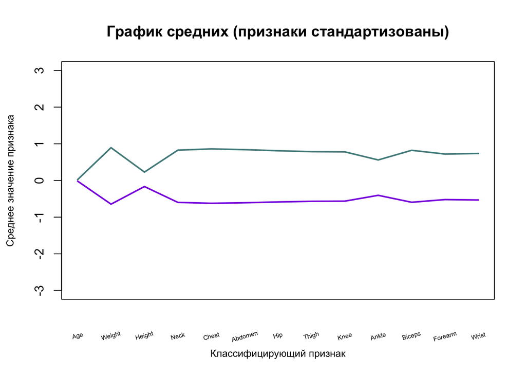

```r
plot(1:ncol(df_del_scaled), kmeans2$centers[1,], xaxt = 'n', type = 'l', col = 'blueviolet',
     cex.sub = 0.3, cex.lab = 0.8, lwd = 2, ylim = c(-3, 3),
     ylab = 'Среднее значение признака', xlab = 'Классифицирующий признак')

lines(1:ncol(df_del_scaled), kmeans2$centers[2,], type = 'l', col = 'darkslategray4', lwd = 2)

title('График средних (признаки стандартизованы)')
legend(0.8, 5, c('Кластер 1', 'Кластер 2'),
       lwd = c(2, 2), col = c('blueviolet','darkslategray4'))
text(x =  seq_along(names(df_del_scaled)), y = par("usr")[3] - 1, srt = 15, adj = 0.5,
     labels = names(df_del_scaled), xpd = TRUE, cex = 0.5)
```

По графику видны некоторые интересные особенности двух кластеров:

#### **4.2. Проверка гипотезы о равенстве средних значений в кластерах**

Тест ANOVA.

Для того, чтобы убедиться в наших выводах, следующим шагом мы проведем тест ANOVA. Поскольку нулевой гипотезой данного теста выступает равенство всех средних значений, то мы будем обращать внимание на значение p-value < 0.05 (меньшее условного уровня значимости в 5%), чтобы зафиксировать, в каких случаях средние всех уровней фактора различны.

```r
pander(summary(aov(df_del_scaled$Age ~ as.factor(kmeans2$cluster))))
```

Analysis of Variance Model

|  | Df | Sum Sq | Mean Sq | F value | Pr(>F) |
| --- | --- | --- | --- | --- | --- |
| **as.factor(kmeans2$cluster)** | 1 | 0.1103 | 0.1103 | 0.1099 | 0.7405 |
| **Residuals** | 246 | 246.9 | 1.004 | NA | NA |

```r
pander(summary(aov(df_del_scaled$Weight ~ as.factor(kmeans2$cluster))))
```

Analysis of Variance Model

|  | Df | Sum Sq | Mean Sq | F value | Pr(>F) |
| --- | --- | --- | --- | --- | --- |
| **as.factor(kmeans2$cluster)** | 1 | 143.4 | 143.4 | 340.4 | 2.612e-48 |
| **Residuals** | 246 | 103.6 | 0.4212 | NA | NA |

```r
pander(summary(aov(df_del_scaled$Height ~ as.factor(kmeans2$cluster))))
```

Analysis of Variance Model

|  | Df | Sum Sq | Mean Sq | F value | Pr(>F) |
| --- | --- | --- | --- | --- | --- |
| **as.factor(kmeans2$cluster)** | 1 | 9.36 | 9.36 | 9.689 | 0.002073 |
| **Residuals** | 246 | 237.6 | 0.966 | NA | NA |

```r
pander(summary(aov(df_del_scaled$Neck ~ as.factor(kmeans2$cluster))))
```

Analysis of Variance Model

|  | Df | Sum Sq | Mean Sq | F value | Pr(>F) |
| --- | --- | --- | --- | --- | --- |
| **as.factor(kmeans2$cluster)** | 1 | 122.5 | 122.5 | 242.2 | 1.747e-38 |
| **Residuals** | 246 | 124.5 | 0.5059 | NA | NA |

```r
pander(summary(aov(df_del_scaled$Chest ~ as.factor(kmeans2$cluster))))
```

Analysis of Variance Model

|  | Df | Sum Sq | Mean Sq | F value | Pr(>F) |
| --- | --- | --- | --- | --- | --- |
| **as.factor(kmeans2$cluster)** | 1 | 132.8 | 132.8 | 286.1 | 4.27e-43 |
| **Residuals** | 246 | 114.2 | 0.4642 | NA | NA |

```r
pander(summary(aov(df_del_scaled$Abdomen ~ as.factor(kmeans2$cluster))))
```

Analysis of Variance Model

|  | Df | Sum Sq | Mean Sq | F value | Pr(>F) |
| --- | --- | --- | --- | --- | --- |
| **as.factor(kmeans2$cluster)** | 1 | 126.6 | 126.6 | 258.7 | 2.869e-40 |
| **Residuals** | 246 | 120.4 | 0.4894 | NA | NA |

```r
pander(summary(aov(df_del_scaled$Hip ~ as.factor(kmeans2$cluster))))
```

Analysis of Variance Model

|  | Df | Sum Sq | Mean Sq | F value | Pr(>F) |
| --- | --- | --- | --- | --- | --- |
| **as.factor(kmeans2$cluster)** | 1 | 117.8 | 117.8 | 224.4 | 1.734e-36 |
| **Residuals** | 246 | 129.2 | 0.5251 | NA | NA |

```r
pander(summary(aov(df_del_scaled$Thigh ~ as.factor(kmeans2$cluster))))
```

Analysis of Variance Model

|  | Df | Sum Sq | Mean Sq | F value | Pr(>F) |
| --- | --- | --- | --- | --- | --- |
| **as.factor(kmeans2$cluster)** | 1 | 110.6 | 110.6 | 199.5 | 1.439e-33 |
| **Residuals** | 246 | 136.4 | 0.5545 | NA | NA |

```r
pander(summary(aov(df_del_scaled$Knee ~ as.factor(kmeans2$cluster))))
```

Analysis of Variance Model

|  | Df | Sum Sq | Mean Sq | F value | Pr(>F) |
| --- | --- | --- | --- | --- | --- |
| **as.factor(kmeans2$cluster)** | 1 | 109.1 | 109.1 | 194.7 | 5.448e-33 |
| **Residuals** | 246 | 137.9 | 0.5605 | NA | NA |

```r
pander(summary(aov(df_del_scaled$Ankle ~ as.factor(kmeans2$cluster))))
```

Analysis of Variance Model

|  | Df | Sum Sq | Mean Sq | F value | Pr(>F) |
| --- | --- | --- | --- | --- | --- |
| **as.factor(kmeans2$cluster)** | 1 | 56.13 | 56.13 | 72.34 | 1.784e-15 |
| **Residuals** | 246 | 190.9 | 0.7759 | NA | NA |

```r
pander(summary(aov(df_del_scaled$Biceps ~ as.factor(kmeans2$cluster))))
```

Analysis of Variance Model

|  | Df | Sum Sq | Mean Sq | F value | Pr(>F) |
| --- | --- | --- | --- | --- | --- |
| **as.factor(kmeans2$cluster)** | 1 | 121.3 | 121.3 | 237.5 | 5.849e-38 |
| **Residuals** | 246 | 125.7 | 0.5109 | NA | NA |

```r
pander(summary(aov(df_del_scaled$Forearm ~ as.factor(kmeans2$cluster))))
```

Analysis of Variance Model

|  | Df | Sum Sq | Mean Sq | F value | Pr(>F) |
| --- | --- | --- | --- | --- | --- |
| **as.factor(kmeans2$cluster)** | 1 | 93.05 | 93.05 | 148.7 | 4.59e-27 |
| **Residuals** | 246 | 154 | 0.6258 | NA | NA |

```r
pander(summary(aov(df_del_scaled$Wrist ~ as.factor(kmeans2$cluster))))
```

Analysis of Variance Model

|  | Df | Sum Sq | Mean Sq | F value | Pr(>F) |
| --- | --- | --- | --- | --- | --- |
| **as.factor(kmeans2$cluster)** | 1 | 97.13 | 97.13 | 159.4 | 1.648e-28 |
| **Residuals** | 246 | 149.9 | 0.6092 | NA | NA |

В результате теста ANOVA делаем вывод, что практически во всех тестах p-value < 0.05, кроме переменной `Age`, из чего следует, что с вероятностью ошибки 5% нулевая гипотеза о равенстве средних всех уровней фактора отвергается в пользу альтернативной гипотезы о том, что между некоторыми уровнями (хотя бы одним из уровней) есть различие в средних значениях. Поскольку у переменной `Age` `p-value=0.7405` больше уровня значимости в 5% (как и любого другого адекватного уровня), то можем сказать, что между всеми уровнями фактора возраста отсутствуют различия в средних значениях. Стоит также отметить, что тест ANOVA показал различия в уровнях фактора `Height` (нулевая гипотеза о равенстве была отвергнула в силу `p-value=0.002073` < 0.05), это значит, что данный признак все же влияет на классификацию, хотя и незначительно.

#### **4.3. Интерпретация полученных результатов (необходимо дать названия кластерам и обосновать их выбор)**

Мы предполагаем, что именно целевая переменная - `BodyFat` является ключевым обоснованием в делении на кластеры, то есть именно она делит все данные в массиве на две категории показателей: “высокий процент жира”, “низкий процент жира”. Это связано с высокой степенью коррелированности этой переменной с остальными признаками:

```r
dff <- cbind(df_del, cluster = kmeans2$cluster) #необходимо загрузить значения кластерных векторов в исходный массив данных
cor(dff$BodyFat, dff$cluster)                #проверяем корреляцию между кластерами и переменной BodyFat
```

```
## [1] 0.5007077
```

Корреляция равная ~0.5 по модулю является умеренной, что подкрепляет наши предположения о возможности разделения наблюдений на кластеры по признаку веса. Положительное значение говорит нам о прямой взаимосвязи между весом и остальными показателями: 1-“низкий процент жира”, 2-“высокий процент жира”, а не наоборот.

#### **4.4. Описание кластеров с помощью графических средств, помогающих обосновать название кластеров**

Дополнительно проиллюстрируем кластеры для более наглядного отображения и дальнейших выводов с помощью главных компонент.

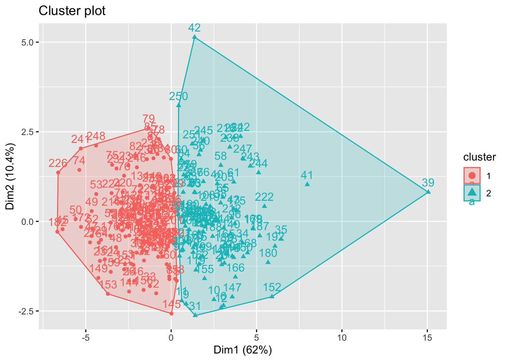

```r
fviz_cluster(kmeans2, data = df_del_scaled)
```

## **5. Построение регрессионных моделей в кластерах (типологическая регрессия)**

#### **5.1. Построение уравнений регрессии в кластерах**

Итак, мы разделили выборку на два кластера и нам необходимо для каждого кластера построить своё уравнение регрессии с теми же переменными, что и входили в уравнение регрессии для всей выборки.

Для начала необходимо разделить выборку на 2 кластера:

```r
class_1 <- subset(dff[dff$cluster == 1, ], select = -c(cluster)) #выделили 1-ый класс и удалили столбец со значениями кластеров
class_2 <- subset(dff[dff$cluster == 2, ], select = -c(cluster)) #выделили 2-ой класс и удалили столбец со значениями кластеров
```

Теперь переходим к построению уравнений регрессии для каждого класса:

```r
lm_class_1 <- lm(BodyFat ~ Age+Weight+Neck+Abdomen+Hip+Thigh+Forearm+Wrist, data = class_1) #регрессионная модель для 1 класса
pander(summary(lm_class_1))
```

|  | Estimate | Std. Error | t value | Pr(>\|t\|) |
| --- | --- | --- | --- | --- |
| **(Intercept)** | -26.9 | 17.59 | -1.529 | 0.1286 |
| **Age** | 0.07794 | 0.04056 | 1.922 | 0.05677 |
| **Weight** | -0.0315 | 0.06614 | -0.4762 | 0.6347 |
| **Neck** | -0.5515 | 0.2974 | -1.855 | 0.06581 |
| **Abdomen** | 0.9105 | 0.1081 | 8.424 | 4.766e-14 |
| **Hip** | -0.07732 | 0.2268 | -0.3409 | 0.7337 |
| **Thigh** | 0.3111 | 0.1956 | 1.59 | 0.1141 |
| **Forearm** | 0.507 | 0.31 | 1.636 | 0.1042 |
| **Wrist** | -2.159 | 0.7594 | -2.843 | 0.00516 |

Fitting linear model: BodyFat ~ Age + Weight + Neck + Abdomen + Hip + Thigh + Forearm + Wrist

| Observations | Residual Std. Error | $R^2$ | Adjusted $R^2$ |
| --- | --- | --- | --- |
| 144 | 4.351 | 0.6347 | 0.613 |

В модели для 1-го класса значимой переменной на уровне 5% является `Abdomen` и `Wrist`, то есть мы можем сказать, что существует статистически значимая связь между `Bodyfat` и `Wrist` (процентом жира в организме и окружностью запястья; `Bodyfat` и `Abdomen` (процентом жира и окружностью живота), что также логично. Скорректированное значение коэффицента детирминации уменьшилось и стало равно 61%.

Построение регрессии для 2-го класса:

```r
lm_class_2 <- lm(BodyFat ~ Age+Weight+Neck+Abdomen+Hip+Thigh+Forearm+Wrist, data = class_2)
pander(summary(lm_class_2))
```

|  | Estimate | Std. Error | t value | Pr(>\|t\|) |
| --- | --- | --- | --- | --- |
| **(Intercept)** | -24.63 | 18.84 | -1.308 | 0.1942 |
| **Age** | 0.06082 | 0.05169 | 1.177 | 0.2423 |
| **Weight** | -0.1154 | 0.05323 | -2.167 | 0.03271 |
| **Neck** | -0.2704 | 0.3685 | -0.7336 | 0.465 |
| **Abdomen** | 0.9564 | 0.105 | 9.113 | 1.303e-14 |
| **Hip** | -0.2222 | 0.1814 | -1.225 | 0.2237 |
| **Thigh** | 0.2803 | 0.1831 | 1.531 | 0.129 |
| **Forearm** | 0.4856 | 0.2539 | 1.913 | 0.05877 |
| **Wrist** | -1.362 | 0.7382 | -1.845 | 0.06816 |

Fitting linear model: BodyFat ~ Age + Weight + Neck + Abdomen + Hip + Thigh + Forearm + Wrist

| Observations | Residual Std. Error | $R^2$ | Adjusted $R^2$ |
| --- | --- | --- | --- |
| 104 | 4.161 | 0.7253 | 0.7022 |

В модели для 2-го класса переменные `Weight` и `Abdomen` являются значимыми на уровне 5%, то есть мы можем сказать, что существует статистически значимая связь между `Bodyfat` и `Weight` (процентом жира в организме и весом тела); `Bodyfat` и `Abdomen` (процентом жира и окружностью живота), что логично. Так же, посмотрев на скорректированное значение коэффициента детерминации, мы делаем вывод, что 70% вариации значений процента жира объясняются данной моделью.

#### **5.2. Сопоставление и интерпретация коэффициентов регрессии в кластерах с использованием коэффициентов эластичности**

Уравнение регрессии для 1 класса:
$$y_{BodyFat} = - 26.9 + 0.07794 \cdot x_{Age} - 0.0315 \cdot x_{Weight}
- 0.5515 \cdot x_{Neck} + 0.9105 \cdot x_{Abdomen} - 0.07732 \cdot
x_{Hip} + 0.3111 \cdot x_{Thigh} + 0.507 \cdot x_{Forearm} - -2.159
\cdot x_{Wrist} +ε_i$$

Уравнение регрессии для 2 класса:
$$y_{BodyFat} = - 24.63 + 0.06082 \cdot x_{Age} - 0.1154 \cdot x_{Weight}
-0.2704 \cdot x_{Neck} + 0.9564 \cdot x_{Abdomen} - -0.2222 \cdot
x_{Hip} + 0.2803 \cdot x_{Thigh} + 0.4856 \cdot x_{Forearm} -
-1.362 \cdot x_{Wrist} +ε_i$$

Для расчёта коэффициентов эластичности необходимо знать предсказанные значения моделей, поэтому сначала сделаем предсказания:

```r
class_1$y_pred = predict(lm_class_1)
class_2$y_pred = predict(lm_class_2)
```

Как мы знаем, коэффициент эластичности показывает на сколько процентов в среднем изменится значени результативного признака `BodyFat` при изменении факторного показателя на 1%. Поэтому будем делать выводы исходя из этого знания, а именно, чем меньше значение коэффициента, тем меньшее влияние оказывает признак на результативный показатель.

```r
paste('Коэффициент эластичности для `Age` класс 1 =', round(0.07794 * mean(class_1$Age)/mean(class_1$y_pred), 2), '%')
```

```
## [1] "Коэффициент эластичности для `Age` класс 1 = 0.22 %"
```

```r
paste('Коэффициент эластичности для `Age` класс 2 =', round(0.06082 * mean(class_2$Age)/mean(class_2$y_pred), 2), '%')
```

```
## [1] "Коэффициент эластичности для `Age` класс 2 = 0.11 %"
```

Наблюдаем, что признак `Age` оказывает незначительное положительное влияние на изменение результативного показателя, но всё-таки более сильное воздействие оказано на 1-ый класс.

```r
paste('Коэффициент эластичности для `Weight` класс 1 =', round(-0.0315 * mean(class_1$Weight)/mean(class_1$y_pred), 2), '%')
```

```
## [1] "Коэффициент эластичности для `Weight` класс 1 = -0.32 %"
```

```r
paste('Коэффициент эластичности для `Weight` класс 2 =', round(-0.1154 * mean(class_2$Weight)/mean(class_2$y_pred), 2), '%')
```

```
## [1] "Коэффициент эластичности для `Weight` класс 2 = -0.99 %"
```

Признак `Weight` оказывает незначительное отрицательное влияние на изменение результативного показателя, но всё-таки более сильное воздействие оказано на 2-ой класс. При увеличении веса на 1%, процент жира в среднем снижается на 0.32% в 1 классе и на 0.99% во 2 классе. Возможно, это связано с ростом мышечной массы.

```r
paste('Коэффициент эластичности для `Neck` класс 1 =', round(-0.5515 * mean(class_1$Neck)/mean(class_1$y_pred), 2), '%')
```

```
## [1] "Коэффициент эластичности для `Neck` класс 1 = -1.3 %"
```

```r
paste('Коэффициент эластичности для `Neck` класс 2 =', round(-0.2704 * mean(class_2$Neck)/mean(class_2$y_pred), 2), '%')
```

```
## [1] "Коэффициент эластичности для `Neck` класс 2 = -0.45 %"
```

Признак `Neck` оказывает малое отрицательное влияние на изменение результативного показателя, но всё-таки более сильное воздействие оказано на 1-ый класс. При увеличении обхвата шеи на 1%, процент жира в среднем снижается на 1.3% в 1 классе и на 0.45% во 2 классе. Это также может быть связано с ростом мышечной массы.

```r
paste('Коэффициент эластичности для `Abdomen` класс 1 =', round(0.9105 * mean(class_1$Abdomen)/mean(class_1$y_pred), 2), '%')
```

```
## [1] "Коэффициент эластичности для `Abdomen` класс 1 = 5.04 %"
```

```r
paste('Коэффициент эластичности для `Abdomen` класс 2 =', round(0.9564 * mean(class_2$Abdomen)/mean(class_2$y_pred), 2), '%')
```

```
## [1] "Коэффициент эластичности для `Abdomen` класс 2 = 4.05 %"
```

Признак `Abdomen` оказывает положительное влияние на изменение результативного показателя и тут изменения процента жира более значимы, но всё-таки более сильное воздействие оказано на 1-ый класс. При увеличении обхвата живота на 1%, процент жира в среднем увеличивается на 5.04% в 1 классе и на 4.05% во 2 классе, что логично, ведь прибавление объёмов в данной части тела действительно связано с ростом жира.

```r
paste('Коэффициент эластичности для `Hip` класс 1 =', round(-0.07732 * mean(class_1$Hip)/mean(class_1$y_pred), 2), '%')
```

```
## [1] "Коэффициент эластичности для `Hip` класс 1 = -0.48 %"
```

```r
paste('Коэффициент эластичности для `Hip` класс 2 =', round(-0.2222 * mean(class_2$Hip)/mean(class_2$y_pred), 2), '%')
```

```
## [1] "Коэффициент эластичности для `Hip` класс 2 = -0.98 %"
```

Признак `Hip` оказывает незначительное отрицательное влияние на изменение результативного показателя. Более сильное влияние оказывается на класс 2. При увеличении объёмов бёдер на 1%, процент жира в среднем снижается на 0.48% в 1 классе и на 0.98% во 2 классе, возможно, это тоже следствие роста именно мышечной массы.

```r
paste('Коэффициент эластичности для `Thigh` класс 1 =', round(0.3111 * mean(class_1$Thigh)/mean(class_1$y_pred), 2), '%')
```

```
## [1] "Коэффициент эластичности для `Thigh` класс 1 = 1.13 %"
```

```r
paste('Коэффициент эластичности для `Thigh` класс 2 =', round(0.2803 * mean(class_2$Thigh)/mean(class_2$y_pred), 2), '%')
```

```
## [1] "Коэффициент эластичности для `Thigh` класс 2 = 0.74 %"
```

Признак `Thigh` оказывает положительное влияние на результативный показатель. Более сильное влияние оказано на 1-ый класс. При увеличении объёма ляжек (часть ноги выше голени) на 1%, процент жира в среднем увеличивается на 1.13% в 1 классе и на 0.74% во 2 классе.

```r
paste('Коэффициент эластичности для `Forearm` класс 1 =', round(0.507 * mean(class_1$Forearm)/mean(class_1$y_pred), 2), '%')
```

```
## [1] "Коэффициент эластичности для `Forearm` класс 1 = 0.9 %"
```

```r
paste('Коэффициент эластичности для `Forearm` класс 2 =', round(0.4856 * mean(class_2$Forearm)/mean(class_2$y_pred), 2), '%')
```

```
## [1] "Коэффициент эластичности для `Forearm` класс 2 = 0.61 %"
```

Признак `Forearm` оказывает положительное влияние на результативный показатель. Более сильное воздействие на 1 класс. При увеличении объёмов в предплечье на 1%, процент жира в среднем увеличивается на 0.9% в 1 классе и на 0.61% во 2 классе.

```r
paste('Коэффициент эластичности для `Wrist` класс 1 =', round(-2.159 * mean(class_1$Wrist)/mean(class_1$y_pred), 2), '%')
```

```
## [1] "Коэффициент эластичности для `Wrist` класс 1 = -2.46 %"
```

```r
paste('Коэффициент эластичности для `Wrist` класс 2 =', round(-1.362  * mean(class_2$Wrist)/mean(class_2$y_pred), 2), '%')
```

```
## [1] "Коэффициент эластичности для `Wrist` класс 2 = -1.07 %"
```

Признак `Wrist` оказывает отрицательное влияние на изменение результативного показателя. Замечаем, что более сильное воздействие на класс 1. При увеличении обхвата запястья на 1%, процент жира в среднем снижается на 2.46% в 1 классе и на 1.07% во 2 классе.

Итак, давайте, упорядочим признаки по воздействию на изменение результативного показателя в каждом классе. Начнеём с более активного влияния (1) и закончим менее влиятельным признаком (8).

| Класс | *1* | *2* | *3* | *4* | *5* | *6* | *7* | *8* |
| --- | --- | --- | --- | --- | --- | --- | --- | --- |
| 1 | `Abdomen` | `Wrist` | `Neck` | `Thigh` | `Forearm` | `Hip` | `Weight` | `Age` |
| 2 | `Abdomen` | `Wrist` | `Weight` | `Hip` | `Thigh` | `Forearm` | `Neck` | `Age` |

Видим, что и в 1 и во 2 классе самый сильно воздействующий признак - `Abdomen` и самый слабо воздействующий на результат - `Age`. Если мы спроецируем наши результаты на реальную жизнь, то это так, высокие значения обхвата живота действительно связаны с высоким процентом жира и в свою очередь возраст почти никак не влияет на значения процента жира. Что интересно, `Weight` с 3 места во 2 классе перешёл на предпоследнее в 1 классе, что ещё раз подкрепляет наши суждения о том, что в 1 класс входят люди с низким процентом жира.

#### **5.3. Сопоставление качества построенных моделей в кластерах и для всей совокупности объектов в целом**

Сначала вспомним характеристику линейной регрессии по всей совокупности:

```r
pander(summary(lm1))
```

|  | Estimate | Std. Error | t value | Pr(>\|t\|) |
| --- | --- | --- | --- | --- |
| **(Intercept)** | -21.54 | 11.69 | -1.843 | 0.06657 |
| **Age** | 0.07198 | 0.03089 | 2.33 | 0.02063 |
| **Weight** | -0.08279 | 0.03999 | -2.07 | 0.03948 |
| **Neck** | -0.489 | 0.2242 | -2.181 | 0.03015 |
| **Abdomen** | 0.9204 | 0.07318 | 12.58 | 2.983e-28 |
| **Hip** | -0.2162 | 0.1385 | -1.56 | 0.12 |
| **Thigh** | 0.3359 | 0.1302 | 2.581 | 0.01045 |
| **Forearm** | 0.5175 | 0.1856 | 2.787 | 0.005736 |
| **Wrist** | -1.511 | 0.5078 | -2.976 | 0.003217 |

Fitting linear model: BodyFat ~ Age + Weight + Neck + Abdomen + Hip + Thigh + Forearm + Wrist

| Observations | Residual Std. Error | $R^2$ | Adjusted $R^2$ |
| --- | --- | --- | --- |
| 251 | 4.267 | 0.7373 | 0.7287 |

Теперь выведем характеристики моделей для каждого класса.

Характеристика линейной регрессии для 1-го класса:

```r
pander(summary(lm_class_1))
```

|  | Estimate | Std. Error | t value | Pr(>\|t\|) |
| --- | --- | --- | --- | --- |
| **(Intercept)** | -26.9 | 17.59 | -1.529 | 0.1286 |
| **Age** | 0.07794 | 0.04056 | 1.922 | 0.05677 |
| **Weight** | -0.0315 | 0.06614 | -0.4762 | 0.6347 |
| **Neck** | -0.5515 | 0.2974 | -1.855 | 0.06581 |
| **Abdomen** | 0.9105 | 0.1081 | 8.424 | 4.766e-14 |
| **Hip** | -0.07732 | 0.2268 | -0.3409 | 0.7337 |
| **Thigh** | 0.3111 | 0.1956 | 1.59 | 0.1141 |
| **Forearm** | 0.507 | 0.31 | 1.636 | 0.1042 |
| **Wrist** | -2.159 | 0.7594 | -2.843 | 0.00516 |

Fitting linear model: BodyFat ~ Age + Weight + Neck + Abdomen + Hip + Thigh + Forearm + Wrist

| Observations | Residual Std. Error | $R^2$ | Adjusted $R^2$ |
| --- | --- | --- | --- |
| 144 | 4.351 | 0.6347 | 0.613 |

Характеристика линейной регрессии для 2-го класса:

```r
pander(summary(lm_class_2))
```

|  | Estimate | Std. Error | t value | Pr(>\|t\|) |
| --- | --- | --- | --- | --- |
| **(Intercept)** | -24.63 | 18.84 | -1.308 | 0.1942 |
| **Age** | 0.06082 | 0.05169 | 1.177 | 0.2423 |
| **Weight** | -0.1154 | 0.05323 | -2.167 | 0.03271 |
| **Neck** | -0.2704 | 0.3685 | -0.7336 | 0.465 |
| **Abdomen** | 0.9564 | 0.105 | 9.113 | 1.303e-14 |
| **Hip** | -0.2222 | 0.1814 | -1.225 | 0.2237 |
| **Thigh** | 0.2803 | 0.1831 | 1.531 | 0.129 |
| **Forearm** | 0.4856 | 0.2539 | 1.913 | 0.05877 |
| **Wrist** | -1.362 | 0.7382 | -1.845 | 0.06816 |

Fitting linear model: BodyFat ~ Age + Weight + Neck + Abdomen + Hip + Thigh + Forearm + Wrist

| Observations | Residual Std. Error | $R^2$ | Adjusted $R^2$ |
| --- | --- | --- | --- |
| 104 | 4.161 | 0.7253 | 0.7022 |

1. Проверим остатки на нормальность распределения с помощью теста Шапиро-Уилка:

```r
pander(shapiro.test(lm1$residuals)) #остатки линейной регрессионной модели
```

Shapiro-Wilk normality test: `lm1$residuals`

| Test statistic | P value |
| --- | --- |
| 0.9939 | 0.4111 |

```r
pander(shapiro.test(lm_class_1$residuals)) #остатки линейной регрессионной модели 1-го класса
```

Shapiro-Wilk normality test: `lm_class_1$residuals`

| Test statistic | P value |
| --- | --- |
| 0.9843 | 0.09923 |

```r
pander(shapiro.test(lm_class_2$residuals)) #остатки линейной регрессионной модели 2-го класса
```

Shapiro-Wilk normality test: `lm_class_2$residuals`

| Test statistic | P value |
| --- | --- |
| 0.9911 | 0.7326 |

Итак, мы видим, что p-value везде больше 5% уровня значимости, значит, гипотеза о нормальном распределении остатков не отвергается.

2. Проверка остатков на независимость с помощью теста Дарбина-Ватсона:

```r
durbinWatsonTest(lm1) #регрессионная модель для всей совокупности
```

```
##  lag Autocorrelation D-W Statistic p-value
##    1      0.09771022      1.796854   0.082
##  Alternative hypothesis: rho != 0
```

```r
durbinWatsonTest(lm_class_1) #регрессионная модель для 1-го класса
```

```
##  lag Autocorrelation D-W Statistic p-value
##    1       0.1630385      1.668165   0.024
##  Alternative hypothesis: rho != 0
```

```r
durbinWatsonTest(lm_class_2) #регрессионная модель для 2-го класса
```

```
##  lag Autocorrelation D-W Statistic p-value
##    1      -0.1171457      2.209166    0.33
##  Alternative hypothesis: rho != 0
```

Здесь мы наблюдаем, что у моделей для всей совокупности и для 2-го класса p-value больше 5% уровня значимости, что говорит о том, что остатки являются независимыми. Для остатков регрессионной модели 1-го класса гипотеза о независимости остатков отвергается, значит, они зависимы.

3. Проверка остатков на гомоскедастичность c помощью теста Бреуша-Пагана:

```r
pander(bptest(lm1))
```

studentized Breusch-Pagan test: `lm1`

| Test statistic | df | P value |
| --- | --- | --- |
| 10.68 | 8 | 0.2202 |

```r
pander(bptest(lm_class_1))
```

studentized Breusch-Pagan test: `lm_class_1`

| Test statistic | df | P value |
| --- | --- | --- |
| 7.834 | 8 | 0.4499 |

```r
pander(bptest(lm_class_2))
```

studentized Breusch-Pagan test: `lm_class_2`

| Test statistic | df | P value |
| --- | --- | --- |
| 4.512 | 8 | 0.8083 |

Итак, везде p-value больше 5% уровня значимости, значит, гипотеза о гомоскедастичности остатков не отвергается.

Давайте сделаем сводную таблицы и подведём итоги о качестве моделей.

| Регрессионная модель | Линейная зависимость | Нормальность остатков | Независимость остатков | Гомоскедастичность остатков | Adjusted $R^2$ |
| --- | --- | --- | --- | --- | --- |
| `lm1` (для всей совокупности) | ✔️ | ✔️ | ✔️ | ✔️ | 72.9% |
| `lm_class_1` (для 1-го класса) | ✔️ | ✔️ | ✖️ | ✔️ | 61.3% |
| `lm_class_2` (для 2-го класса) | ✔️ | ✔️ | ✔️ | ✔️ | 70.2% |

Итак, смотря на таблицу понимаем, что лучшая по качеству модель - линейная регрессионная модель для всей выборки. Во-первых, у неё выполнены все предпосылки регрессионной модели, что говорит о надёжности результатов, но данные предпосылки выполняются и у модели для 2-го класса. Во-вторых, смотрим на скорректированный коэффициент детерминации, который больше всех представленных, что говорит, что моделью `lm1` объясняется почти 73% разброса значений процентов жира.

Также, мы вспомнили про критерий Акаике и Шварца, но в данном разделе он не применим, так как AIC и BIC зависят от размера выборок, а они здесь разные, что приведёт к ошибочным выводам.

## **6. Дискриминантный анализ**

#### **6.1. Построение дискриминантных функций. Выводы о качестве модели**

Для проведения дискриминантного анализа используем результаты k-means из пункта 4. Там было получено 2 кластера.

```r
set.seed(1)
kmeans2 <- kmeans(df_del_scaled, centers = 2)
```

Присоединим вектор значений принадлежности к кластеру к основным уже отмасштабированным данным:

```r
clusters <- kmeans2$cluster
df_6 <- as.data.frame(cbind(df_del_scaled, clusters))
```

Делим выборку на обучающую (2/3) и тестовую (1/3):

```r
smpl_size <- floor(2/3 * nrow(df_6))

set.seed(1)
train_ind <- sample(seq_len(nrow(df_6)), size = smpl_size)

data.train <- as.data.frame(df_6[train_ind,])
data.test <- as.data.frame(df_6[-train_ind,])
```

Строим дискриминантную функцию:

```r
lda.fit <- lda(data.train[,-c(14)], data.train$clusters) #-c(14) - убираем 14 колонку с номерами кластеров
lda.fit
```

```
## Call:
## lda(data.train[, -c(14)], data.train$clusters)
##
## Prior probabilities of groups:
##         1         2
## 0.5939394 0.4060606
##
## Group means:
##           Age     Weight     Height       Neck      Chest    Abdomen        Hip
## 1  0.05541549 -0.6699983 -0.1879062 -0.6160778 -0.6444951 -0.5968821 -0.6008762
## 2 -0.01929276  0.9193755  0.1663105  0.8195042  0.8903915  0.8943758  0.8586517
##        Thigh       Knee      Ankle     Biceps    Forearm      Wrist
## 1 -0.6207568 -0.6241011 -0.4834178 -0.6356803 -0.5823041 -0.5619891
## 2  0.8040551  0.8244539  0.5276323  0.8466638  0.6545481  0.6828729
##
## Coefficients of linear discriminants:
##                  LD1
## Age     -0.333038397
## Weight  -0.005849075
## Height  -0.075259982
## Neck     0.041428827
## Chest    0.332864750
## Abdomen  0.878112270
## Hip     -0.684320249
## Thigh   -0.053267212
## Knee     0.524775204
## Ankle    0.017163136
## Biceps   0.426930079
## Forearm  0.150941867
## Wrist    0.282502235
```

Графически:

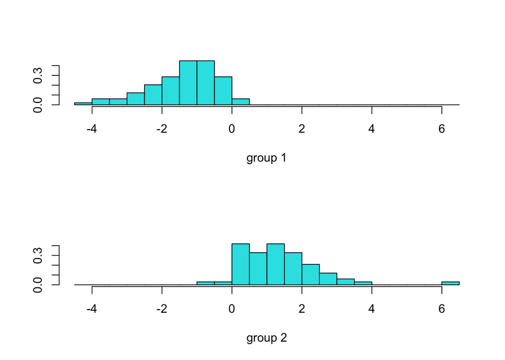

```r
plot(lda.fit)
```

По графику видим, что группы имеют разный разброс значений, но при этом есть пересечение в 0, следовательно, можно предварительно сказать, что эти группы отличимы друг от друга и нормальное разбиение на кластеры возможно, но не утверждать.

Прогнозы на тестовой выборке:

```r
lda.pred <- predict(lda.fit, data.test[,-c(14)])
```

Гистограмма значений дискриминантной функции:

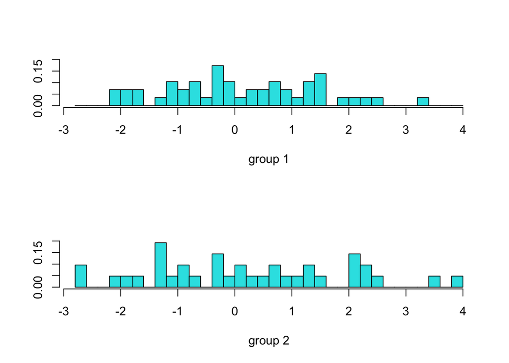

```r
ldahist(data = lda.pred$x[,1], g = clusters)
```

Наблюдаем, что значения для разных групп пересекаются, что может сформировать ненадёжные выводы.

Перейдем к лямбде Уилкса, которая показывает, значимо ли различаются между собой средние значения дискриминантной функции в исследуемых группах:

```r
ldam <- manova(as.matrix(data.test[,-c(14)]) ~ lda.pred$class)

pander(summary(ldam, test = "Wilks"))
```

|  | Df | Wilks | approx F | num Df | den Df | Pr(>F) |
| --- | --- | --- | --- | --- | --- | --- |
| **lda.pred$class** | 1 | 0.2736 | 14.09 | 13 | 69 | 1.139e-14 |
| **Residuals** | 81 | NA | NA | NA | NA | NA |

Видим, что `p-value` приблизительно 0, значит, при сравнении с любым разумным уровнем значимости, гипотеза о сходстве средних отвергается, то есть средние исследуемых групп значимо различаются, из чего следует доказательство о наличии дискриминирующих особенностей переменных и о качественном разделении данных по классам. Также мы убеждаемся в этом, когда смотрим на `лямбду Уилкса = 0.2736`, значение которой близко к 0.

#### **6.2. Отнесение новых объектов (3-4 наблюдения) к выделенным и описанным кластерам различными способами с использованием ДФ**

Отобранные раннее (в 3 пункте) наблюдения (новые объекты):

```r
set.seed(1)
rand_df <- df[sample(nrow(df), size = 4), ]
rand_df
```

```
##     BodyFat Age Weight Height Neck Chest Abdomen   Hip Thigh Knee Ankle Biceps
## 249    33.6  72 201.00  69.75 40.9 108.5   105.0 104.5  59.6 40.8  23.2   35.2
## 68     13.8  55 154.75  71.50 36.9  95.4    86.6  91.8  54.3 35.4  21.5   32.8
## 167    21.8  35 166.25  68.00 38.5  99.1    90.4  95.6  55.5 34.2  21.9   30.2
## 129    20.8  40 192.25  73.25 39.8 103.9    93.5  99.5  61.7 39.0  21.8   33.3
##     Forearm Wrist
## 249    28.6  20.1
## 68     27.4  18.7
## 167    28.7  17.7
## 129    29.6  18.1
```

Давайте, удалим целевую переменную и отмасштабируем:

```r
rand_df_new <- scale(rand_df)
rand_df_new <- data.frame(rand_df_new)
rand_df_new <- rand_df_new[-c(1)]
rand_df_new
```

```
##            Age     Weight     Height       Neck      Chest     Abdomen
## 249  1.2902581  1.0351769 -0.3872983  1.0881380  1.1882461  1.40196137
## 68   0.2700540 -1.0986140  0.3872983 -1.2332231 -1.1093220 -0.91678822
## 167 -0.9301861 -0.5680497 -1.1618950 -0.3046786 -0.4603905 -0.43791602
## 129 -0.6301260  0.6314868  1.1618950  0.4497637  0.3814664 -0.04725712
##            Hip      Thigh      Knee      Ankle      Biceps     Forearm
## 249  1.2236040  0.5269236  1.122285  1.4612646  1.12790124  0.02767829
## 68  -1.1132037 -1.0033203 -0.634335 -0.7970534 -0.03638391 -1.30087972
## 167 -0.4140014 -0.6568500 -1.024695 -0.2656845 -1.29769282  0.13839146
## 129  0.3036010  1.1332467  0.536745 -0.3985267  0.20617550  1.13480997
##           Wrist
## 249  1.38043077
## 68   0.04760106
## 167 -0.90442016
## 129 -0.52361167
```

Теперь сделаем прогноз для этих наблюдений при помощи дискриминатной функции, построенной на основе метода k-means:

```r
lda4.pred <- predict(lda.fit, rand_df_new)
lda4.pred <- data.frame(lda4.pred)
head(lda4.pred)
```

```
##     class posterior.1 posterior.2        LD1
## 249     2  0.01391186  0.98608814  1.9497903
## 68      1  0.97916809  0.02083191 -1.0074157
## 167     1  0.98385501  0.01614499 -1.1020799
## 129     2  0.49655034  0.50344966  0.4013354
```

Исходя из апостериорных вероятностей каждое наблюдение было определено в какой-то класс. Интересно, что наблюдение 129 имеет вероятность 50/50 по распределению в 1 и 2 класс, но всё-таки немного перевесил 2 класс.

Давайте посмотрим на значения процента жира для каждого наблюдения:

```r
rand_df[c('BodyFat')]
```

```
##     BodyFat
## 249    33.6
## 68     13.8
## 167    21.8
## 129    20.8
```

Видим, что наблюдение 249 имеет 33.6% жира и его предсказанный класс - 2 (“высокий процент жира”); 68 имеет 13.8% жира и его класс - 1 (“низкий процент жира”); 167 имеет 21.8% жира и его класс - 1 (“низкий процент жира”) и 129 имеет 20.8% жира и его класс - 2 (“высокий процент жира”). Заметим, что 167 наблюдение имеет процент жира выше, чем 129 наблюдение и при этом 167 наблюдение попало в класс с низким процентом жира, а 129 наоборот с высоким, и вспомним, про пограничное состояние наблюдения 129, значит, всё-таки данное наблюдение было неправильно классифицировано. В остальном, по смыслу всё определено верно.

В пункте 2 было выявляно, что нашим данным не подходит иерархическая кластеризация, поэтому остановимся только на отнесении новых объектов к выделенным кластерам на основе итеративного метода k-means.

#### **6.3. Уточнение результатов классификации, выполненной с помощью метода к-средних, с помощью аппарата дискриминантного анализа (выявление некорректно классифицированных наблюдений)**

Давайте посмотрим как тестовые данные распределены по классам:

```r
pander(table(data.test$clusters))
```

| 1 | 2 |
| --- | --- |
| 46 | 37 |

Видим, что в классе 1 - 46 наблюдений, в классе 2 - 37.

Далее посмотрим на распределение прогнозов, сделанных на тестовой выборке, по классам:

```r
pander(summary(lda.pred$class))
```

| 1 | 2 |
| --- | --- |
| 47 | 36 |

Видим, что в классе 1 - 47 наблюдений, в классе 2 - 36. Понимаем, что есть предсказанный класс не соответствует истинному.

Матрица ошибок:

```r
table(lda.pred$class, data.test[,c("clusters")])
```

```
##
##      1  2
##   1 43  4
##   2  3 33
```

Давайте посмотрим на выявленные некорректно классифицированные наблюдения:

```r
which(data.test$clusters != lda.pred$class)
```

```
## [1]  3  5  6 36 47 69 76
```

Видим, что наблюдения 3, 5, 6, 36, 47, 69, 76 были неправильно классифицированны.

#### **6.4. Анализ классификационной матрицы (classification matrix). Вывод о качестве разбиения объектов на кластеры**

Таблица соответствия предсказанных классов исходным:

```r
misclass <- function(pred, obs) { tbl <- table(pred, obs)
sum <- colSums(tbl)
dia <- diag(tbl)
msc <- ((sum - dia)/sum) * 100
m.m <- mean(msc)
cat("Classification table:", "\n")
print(tbl)
cat("Misclassification errors:", "\n")
print(round(msc, 2))

print(round(m.m, 2))}

misclass(lda.pred$class, data.test[,c("clusters")])
```

```
## Classification table:
##     obs
## pred  1  2
##    1 43  4
##    2  3 33
## Misclassification errors:
##     1     2
##  6.52 10.81
## [1] 8.67
```

#### **6.5. Построение графика принадлежности тестовой и тренировочной выборок к кластерам по результатам проведенного анализа**

Вновь отобразим график значений дискриминантной функции на обучающей выборке:

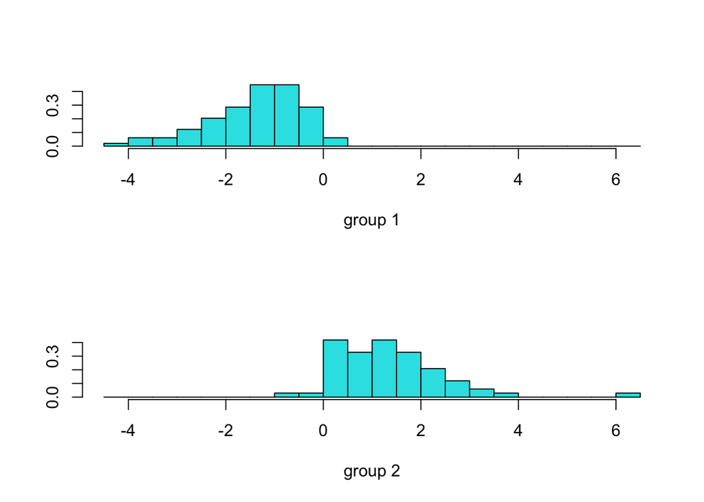

```r
plot(lda.fit)
```

График предсказанный значений на тестовой выборке:

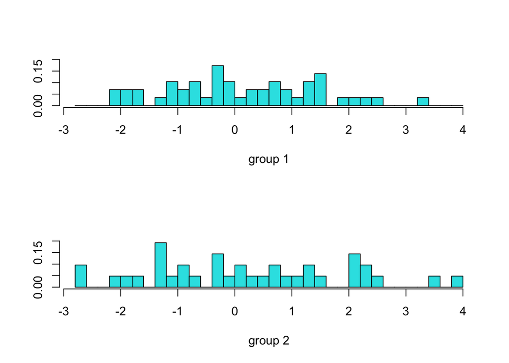

```r
ldahist(data = lda.pred$x[,1], g = clusters)
```

Как говорилось выше, видим, что предсказанные значения в разных группах пересекаются, что может привести к неправильным выводам, таким образом мы и получили неверную классификацию 7 объектов, которые были выявлены в прошлом пункте.